# Intro to Data Science HW 7

##### Copyright Jeffrey Stanton, Jeffrey Saltz, and Jasmina Tacheva

```r
# Enter your name here: Mark Cappiello
```

### Attribution statement: (choose only one and delete the rest)

```r
# 2. I did this homework with help from the book and the professor and these Internet sources: I also recently bought a book called "Learning R" written by Richard Cotton published by O'Reilly Media Inc. 2013
```

The chapter on **linear models** (“Lining Up Our Models”) introduces **linear predictive modeling** using the tool known as **multiple regression**. The term “multiple regression” has an odd history, dating back to an early scientific observation of a phenomenon called **“regression to the mean.”** These days, multiple regression is just an interesting name for using **linear modeling** to assess the **connection between one or more predictor variables and an outcome variable**.

In this exercise, you will **predict Ozone air levels from three predictors**.

1. We will be using the **airquality** data set available in R. Copy it into a dataframe called **air** and use the appropriate functions to **summarize the data**.

```r
air <- airquality
str(air)
```

```
## 'data.frame':    153 obs. of  6 variables:
##  $ Ozone  : int  41 36 12 18 NA 28 23 19 8 NA ...
##  $ Solar.R: int  190 118 149 313 NA NA 299 99 19 194 ...
##  $ Wind   : num  7.4 8 12.6 11.5 14.3 14.9 8.6 13.8 20.1 8.6 ...
##  $ Temp   : int  67 72 74 62 56 66 65 59 61 69 ...
##  $ Month  : int  5 5 5 5 5 5 5 5 5 5 ...
##  $ Day    : int  1 2 3 4 5 6 7 8 9 10 ...
```

```r
summary(air)
```

```
##      Ozone           Solar.R           Wind             Temp
##  Min.   :  1.00   Min.   :  7.0   Min.   : 1.700   Min.   :56.00
##  1st Qu.: 18.00   1st Qu.:115.8   1st Qu.: 7.400   1st Qu.:72.00
##  Median : 31.50   Median :205.0   Median : 9.700   Median :79.00
##  Mean   : 42.13   Mean   :185.9   Mean   : 9.958   Mean   :77.88
##  3rd Qu.: 63.25   3rd Qu.:258.8   3rd Qu.:11.500   3rd Qu.:85.00
##  Max.   :168.00   Max.   :334.0   Max.   :20.700   Max.   :97.00
##  NA's   :37       NA's   :7
##      Month            Day
##  Min.   :5.000   Min.   : 1.0
##  1st Qu.:6.000   1st Qu.: 8.0
##  Median :7.000   Median :16.0
##  Mean   :6.993   Mean   :15.8
##  3rd Qu.:8.000   3rd Qu.:23.0
##  Max.   :9.000   Max.   :31.0
##
```

```r
#glimpse(air)
head(air, 5)
```

```
##   Ozone Solar.R Wind Temp Month Day
## 1    41     190  7.4   67     5   1
## 2    36     118  8.0   72     5   2
## 3    12     149 12.6   74     5   3
## 4    18     313 11.5   62     5   4
## 5    NA      NA 14.3   56     5   5
```

2. In the analysis that follows, **Ozone** will be considered as the **outcome variable**, and **Solar.R**, **Wind**, and **Temp** as the **predictors**. Add a comment to briefly explain the outcome and predictor variables in the dataframe using **?airquality**.

```r
#?airquality
#--- outcome variable   Ozone   numeric Ozone (ppb)
#--- predictor  Solar.R numeric Solar R (lang)
#--- predictor  Wind    numeric Wind (mph)
#--- predictor  Temp    numeric Temperature (degrees F)
#--- predictor  Month   numeric Month (1--12)
#--- predictor  Day numeric Day of month (1--31)
```

3. Inspect the outcome and predictor variables – are there any missing values? Show the code you used to check for that.

```r
na_values <- is.na(air)
head(na_values, 5)
```

```
##      Ozone Solar.R  Wind  Temp Month   Day
## [1,] FALSE   FALSE FALSE FALSE FALSE FALSE
## [2,] FALSE   FALSE FALSE FALSE FALSE FALSE
## [3,] FALSE   FALSE FALSE FALSE FALSE FALSE
## [4,] FALSE   FALSE FALSE FALSE FALSE FALSE
## [5,]  TRUE    TRUE FALSE FALSE FALSE FALSE
```

4. Use the **na_interpolation()** function from the **imputeTS package** (remember this was used in a previous HW) to fill in the missing values in each of the 4 columns. Make sure there are no more missing values using the commands from Step C.

```r
#install.packages("imputeTS")
library(imputeTS)
air_no_nas <- apply(air, 2, na_interpolation)
air_no_nas <- as.data.frame(air_no_nas)
head(air_no_nas, 5)
```

```
##   Ozone  Solar.R Wind Temp Month Day
## 1    41 190.0000  7.4   67     5   1
## 2    36 118.0000  8.0   72     5   2
## 3    12 149.0000 12.6   74     5   3
## 4    18 313.0000 11.5   62     5   4
## 5    23 308.3333 14.3   56     5   5
```

```r
na_values2 <- is.na(air_no_nas)
head(na_values2, 5)
```

```
##      Ozone Solar.R  Wind  Temp Month   Day
## [1,] FALSE   FALSE FALSE FALSE FALSE FALSE
## [2,] FALSE   FALSE FALSE FALSE FALSE FALSE
## [3,] FALSE   FALSE FALSE FALSE FALSE FALSE
## [4,] FALSE   FALSE FALSE FALSE FALSE FALSE
## [5,] FALSE   FALSE FALSE FALSE FALSE FALSE
```

5. Create **3 bivariate scatterplots (X-Y) plots** (using ggplot), for each of the predictors with the outcome. **Hint:** In each case, put **Ozone on the Y-axis**, and a **predictor on the X-axis**. Add a comment to each, describing the plot and explaining whether there appears to be a **linear relationship** between the outcome variable and the respective predictor.

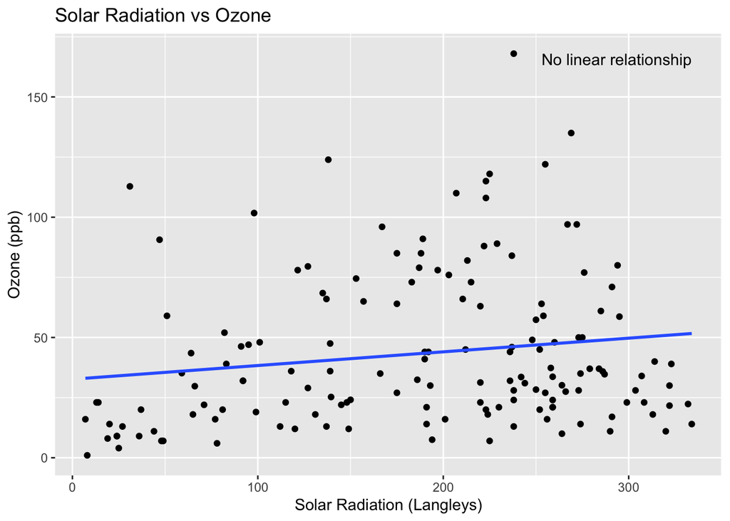

```r
library(ggplot2)

#--- Scatterplot for Solar.R vs Ozone
ggplot(air_no_nas, aes(x = Solar.R, y = Ozone)) +
  geom_point() + labs(title = "Solar Radiation vs Ozone",
       x = "Solar Radiation (Langleys)", y = "Ozone (ppb)") +
  geom_smooth(method = "lm", se = FALSE) +
  annotate("text", x = max(air_no_nas$Solar.R, na.rm = TRUE),
           y = max(air_no_nas$Ozone,na.rm = TRUE),
           label = "No linear relationship", hjust = 1, vjust = 1)
```

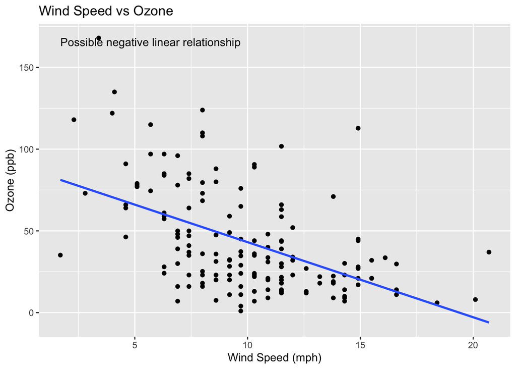

```r
# Scatterplot for Wind vs Ozone
ggplot(air_no_nas, aes(x = Wind, y = Ozone)) +
  geom_point() + labs(title = "Wind Speed vs Ozone",
       x = "Wind Speed (mph)", y = "Ozone (ppb)") +
  geom_smooth(method = "lm", se = FALSE) +
  annotate("text", x = min(air_no_nas$Wind, na.rm = TRUE),
           y = max(air_no_nas$Ozone, na.rm = TRUE),
           label = "Possible negative linear relationship", hjust = 0, vjust = 1)
```